# Question

In a deck of strange cards, there are 383 cards. Each card has an image and a color.

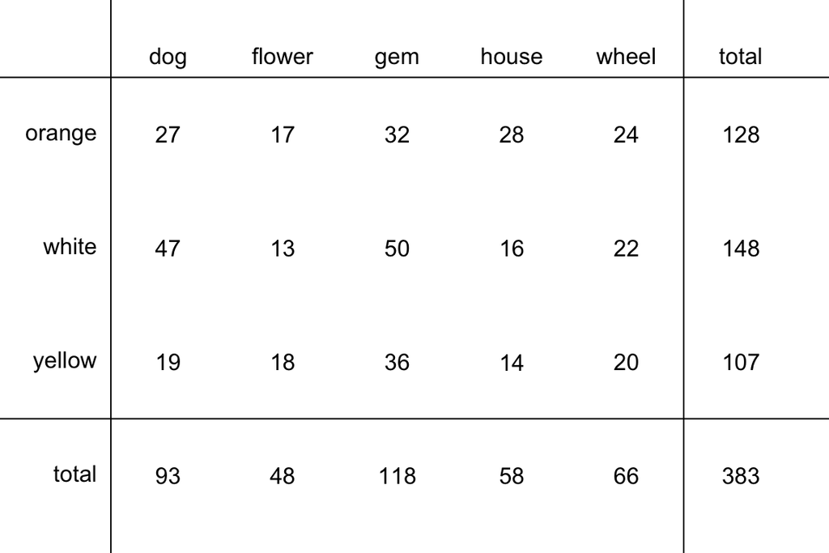

(Answers can be rounded to nearest hundredth.)

1. What is the probability a random card is yellow given it is a dog? ##ANSWER1##
2. What is the probability a random card is a wheel given it is orange? ##ANSWER2##
3. What is the probability a random card is both a dog and white? ##ANSWER3##
4. What is the probability a random card is either a gem or orange (or both)? ##ANSWER4##
5. What is the probability a random card is a wheel? ##ANSWER5##
6. Between a dog and a wheel, which is more likely to be a white? ##ANSWER6##
7. What is the probability a random card is orange? ##ANSWER7##

## Answerlist

- 0.04
- 0.08
- 0.11
- 0.20
- 0.09
- 0.15
- 0.19
- 0.84
- 0.12
- 0.25
- 0.29
- 0.63
- 0.08
- 0.36
- 0.56
- 0.61
- 0.01
- 0.15
- 0.17
- 0.64
- A dog.
- A wheel.
- 0.06
- 0.08
- 0.18
- 0.33

# Solution

[video](https://vimeo.com/531915456)

The key logical terms are “[and](https://en.wikipedia.org/wiki/Logical_conjunction)”, “[or](https://en.wikipedia.org/wiki/Logical_disjunction)”, and “[given](https://en.wikipedia.org/wiki/Conditional_probability)”. Notice that I am using “given” as a shorter version of “under the condition”.

## Answerlist

- $\mathbb{P}[\text{yellow given dog}]=\frac{19}{93}=0.2$
- $\mathbb{P}[\text{wheel given orange}]=\frac{24}{128}=0.19$
- $\mathbb{P}[\text{dog and white}]=\frac{47}{383}=0.12$
- $\mathbb{P}[\text{gem or orange}]=\frac{118+128-32}{383}=0.56$
- $\mathbb{P}[\text{wheel}]=\frac{66}{383}=0.17$
- $\mathbb{P}[\text{white given dog}] = 0.51$ and $\mathbb{P}[\text{white given wheel}] = 0.33$, so a dog is more likely to be white than a wheel is.
- .
- $\mathbb{P}[\text{orange}]=\frac{128}{383}=0.33$

# Meta-information

extype: cloze exsolution: 0001|0010|1000|0010|0010|10|0001 exclozetype: schoice|schoice|schoice|schoice|schoice|schoice|schoice exname: Cards_probabilities extol: 0.01 exextra[numwidth,logical]: TRUE